# Study1_MotivationAging-Reinforcement_Analyses

Debbie Yee

4/29/2018

# Study 1: Age-Related Differences in Motivational Integration and Cognitive Control: Liquid Feedback as Reinforcement

This is an analysis of subject task performance in study 1 in the motivation aging study, in which we examine age-related differences in how individuals integrate the motivational value of monetary and liquid studies, and whether and how this integrated motivational value interacts with cognitive control. In the study, subjects perform a cued task-switching paradigm, where they have classify a letter (vowel/consonant) or digit (odd/even). During the baseline runs, they don’t receive any feedback and are told to respond “as quickly and accurate as possible.” During the incentive runs, they receive a drop of liquid (2 mL) to indicate successful attainment of monetary reward in a single trial. Each subject performs 3 incentive runs in which they must respond accurately and faster than a criterion RT to earn monetary reward. Liquid feedback (blocked) served as reinforcement and signaled successful attainment of monetary reward. Criterion RT is calculated on subject performance during the baseline run (30%).

# Loading relevant packages

```r
library(ggplot2)
library(gridExtra)
library(dplyr)
library(tidyr)
library(broom)
library(lme4)
library(lmerTest)
library(sjPlot)
library(pander)
source("summarySEwithin2.R")
library(RColorBrewer)
```

# Specify colors

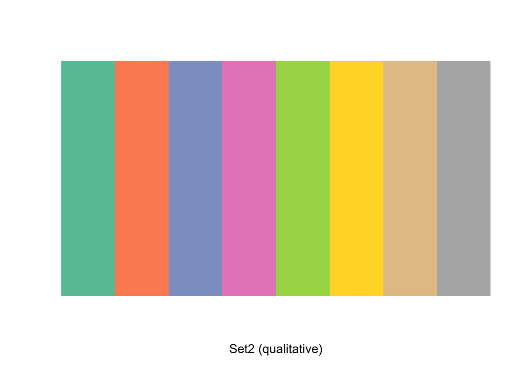

```r
display.brewer.pal(n = 8, name = 'Set2')
```

```r
brewer.pal(n = 8, name = "Set2")
```

```
## [1] "#66C2A5" "#FC8D62" "#8DA0CB" "#E78AC3" "#A6D854" "#FFD92F" "#E5C494"
## [8] "#B3B3B3"
```

```r
colors.OAYA<-c("#66C2A5","#FC8D62")
```

# Path Directories of Data Input/Output

```r
# data directories
data.path<-paste0("/Users/debbieyee/Box Sync/CCPLab_Liquid_Studies_ARCHIVE/",
                  "2018_MotivationAging/Study1_OA_Reinforcement/SubjectData/",
                  "TrimmedData/OAYA_LiqPos_RewardData.csv")
runkey.path<-paste0("/Users/debbieyee/Box Sync/CCPLab_Liquid_Studies_ARCHIVE/",
                    "2018_MotivationAging/Study1_OA_Reinforcement/SubjectData/",
                    "TrimmedData/OAYA_LiqPos_runkey.csv")
runkey.path<-paste0("/Users/debbieyee/Box Sync/CCPLab_Liquid_Studies_ARCHIVE/",
                    "2018_MotivationAging/Study1_OA_Reinforcement/SubjectData/",
                    "TrimmedData/OAYA_LiqPos_runkey.csv")
figure.path<-paste0("/Users/debbieyee/Box Sync/CCPLab_Liquid_Studies_ARCHIVE/",
                    "2018_MotivationAging/MotivationAging_Analyses/Figures")
```

# Format the Data For Analysis

```r
# Read in the data
data<-read.csv(data.path,header = TRUE) %>% select(-X)
runkey<-read.csv(runkey.path, header = TRUE) %>% filter(include=="yes")

# Formatting incentive data
incentive<- data %>% inner_join(y = runkey, by = c("subID","block","group"))  %>%
  mutate(subRewarded=(RT<critRT & ACC==1)*1,
         ERR=ifelse(ACC==0,1,0),
         block=factor(block, levels=c(7,8,9), labels=c(1,2,3)),
         money=factor(rewType, levels=c("Reward1","Reward2","Reward4"), labels=c("$","$$","$$$$")),
         moneyCode=factor(rewType, levels=c("Reward1","Reward2","Reward4"), labels=c(-1,0,1)),
         liqCode=factor(liquid, levels=c("saltwater","neutral","juice"), labels=c(-1,0,1)),
         liqCodeJvN=factor(liquid, levels=c("saltwater","neutral","juice"), labels=c(0,-1,1)),
         liqCodeSvN=factor(liquid, levels=c("saltwater","neutral","juice"), labels=c(-1,1,0)),
         groupCode=factor(group, levels=c("YA","OA"), labels=c(0,1)),
         blockCode=factor(block, levels=c(1,2,3), labels=c(-1,0,1)))
incentive$moneyCode<-as.numeric(levels(incentive$moneyCode)[incentive$moneyCode])
incentive$liqCode<-as.numeric(levels(incentive$liqCode)[incentive$liqCode])
incentive$liqCodeJvN<-as.numeric(levels(incentive$liqCodeJvN)[incentive$liqCodeJvN])
incentive$liqCodeSvN<-as.numeric(levels(incentive$liqCodeSvN)[incentive$liqCodeSvN])
incentive$groupCode<-as.numeric(levels(incentive$groupCode)[incentive$groupCode])
incentive$blockCode<-as.numeric(levels(incentive$blockCode)[incentive$blockCode])
```

```r
# Calculate average monetary earnings per group
test<-incentive %>% filter(group=="YA") %>% group_by(subID) %>% summarise(totalreward=sum(moneyearned))
mean(test$totalreward)
```

```
## [1] 4.499444
```

```r
sd(test$totalreward)
```

```
## [1] 0.7665148
```

```r
test<-incentive %>% filter(group=="OA") %>% group_by(subID) %>% summarise(totalreward=sum(moneyearned))
mean(test$totalreward)
```

```
## [1] 3.940227
```

```r
sd(test$totalreward)
```

```
## [1] 0.7635672
```

# Summarise/Consolidate Incentive Data

```r
# summarise means by subject
groupRT.means = incentive %>% group_by(subID, group) %>%
  filter(!is.na(subRewarded), ACC==1) %>% filter(!is.na(subRewarded), ACC==1) %>%
  summarise(n=n(),meanRT = mean(RT))
group.means = incentive %>% group_by(subID, group) %>% filter(!is.na(subRewarded)) %>%
  summarise(n=n(), meanRR = mean(subRewarded), seRR= sd(subRewarded)/sqrt(length(subRewarded)),
            meanACC = mean(ACC), meanERR = mean(ERR))

# summarise means by monetary reward only
rewRT.means = incentive %>% group_by(subID, money, group, block) %>%
  filter(!is.na(subRewarded), ACC==1) %>% filter(!is.na(subRewarded), ACC==1) %>%
  summarise(n=n(),meanRT = mean(RT))
rew.means = incentive %>% group_by(subID,money, group, block) %>% filter(!is.na(subRewarded)) %>%
  summarise(n=n(), meanRR = mean(subRewarded), meanACC = mean(ACC), meanERR = mean(ERR))

# summarise means by liquid incentive type only
liqRT.means = incentive %>% group_by(subID, liquid, group, block) %>% filter(!is.na(subRewarded), ACC==1) %>%
  summarise(meanRT = mean(RT))
liq.means=incentive %>% group_by(subID, liquid, group, block) %>% filter(!is.na(subRewarded)) %>%
  summarise(n=n(), meanRR = mean(subRewarded), meanACC = mean(ACC), meanERR = mean(ERR))

# summarise the means of the incentive data for each subject, grouped by condition
incentive9RT.means <- incentive %>% group_by(subID, liquid, money, group, block) %>%
  filter(!is.na(subRewarded), ACC==1) %>% summarise(n=n(), meanRT = mean(RT)) %>%
  mutate(moneycode = as.numeric(as.character(factor(money,levels=c("$","$$","$$$$"),
                                                    labels=c(-1,0,1)))),
         liqcode = as.numeric(as.character(factor(liquid,levels=c("saltwater","neutral","juice"),
                                                  labels=c(-1,0,1))))) %>%
  ungroup(subID) %>% mutate(subID=as.factor(subID))
incentive9.means = incentive %>% group_by(subID, liquid, money, group, block) %>%
  filter(!is.na(subRewarded)) %>%
  summarise(n = n(), meanRR = mean(subRewarded), meanACC = mean(ACC), meanERR = mean(ERR)) %>%
  mutate(moneycode = as.numeric(as.character(factor(money,levels=c("$","$$","$$$$"),
                                                    labels=c(-1,0,1)))),
         liqcode = as.numeric(as.character(factor(liquid,levels=c("saltwater","neutral","juice"),
                                                  labels=c(-1,0,1))))) %>%
  ungroup(subID) %>% mutate(subID=as.factor(subID))
```

# Reward Rate Plots

## Plot: histogram of reward rate by age group

```r
RR.sum=summarySE2(data=group.means, measurevar = "meanRR", groupvars = c("group"))
pandoc.table(RR.sum)
```

```
##
## --------------------------------------------------
##  group   N    meanRR     sd       se        ci
## ------- ---- -------- -------- --------- ---------
##   OA     44   0.5769   0.1146   0.01727   0.03483
##
##   YA     54   0.6445   0.1159   0.01577   0.03162
## --------------------------------------------------
```

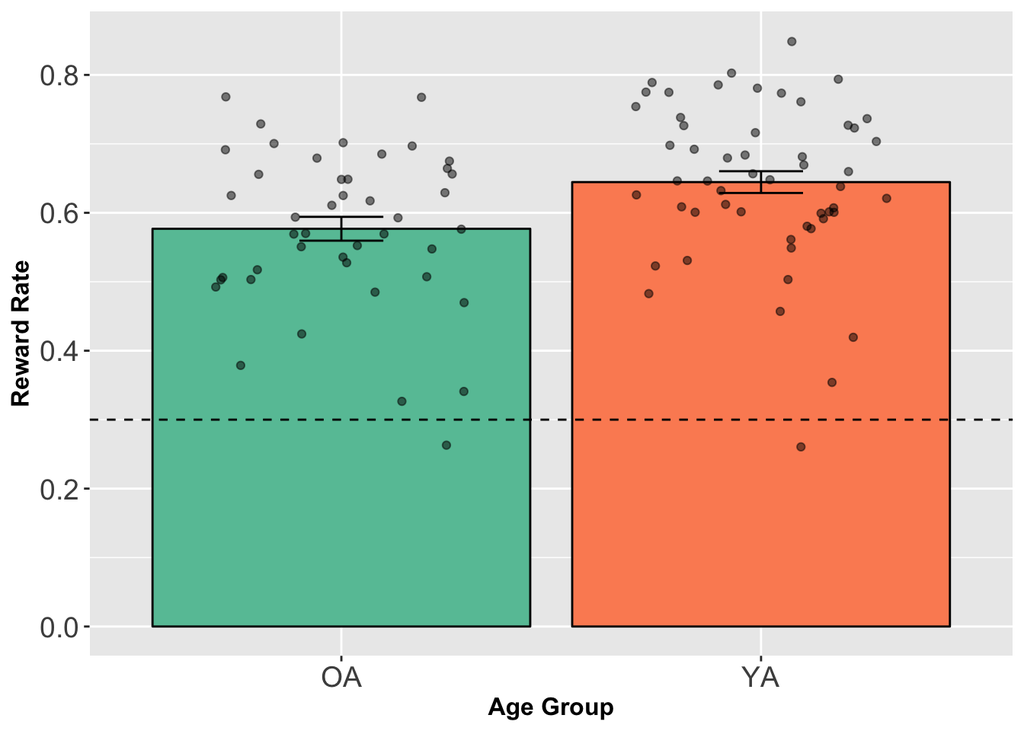

```r
p.RR.0<-ggplot() +
  geom_bar(data = RR.sum, aes(x=group, y=meanRR, fill=group),
           color="black", fill=colors.OAYA, stat="identity") +
  geom_errorbar(data = RR.sum,
                mapping=aes(x=group, y=meanRR,
                            ymin=meanRR-se, ymax=meanRR+se),
                stat="identity", width=0.2) +
  geom_point(data = group.means, aes(x=group, y=meanRR),
             stat="identity", position=position_jitter(w=.3), alpha=0.5) +
  geom_hline(yintercept = .30, linetype="dashed") +
  xlab("Age Group") + ylab("Reward Rate") +
  coord_cartesian(ylim=c(0,.85)) +
  theme(#plot.title=element_text(size=22,face="bold", vjust=2),
        axis.title=element_text(size=12,face = "bold"),
        axis.text=element_text(size=14),
        legend.position="none",
        strip.text.x = element_text(size = 12))
p.RR.0
```

## Plot: mean reward rate by monetary reward and age group

```r
RR.sum=summarySEwithin2(data=rew.means, measurevar = "meanRR", withinvars = c("money"),
                        betweenvars = c("group"), idvar = "subID")
pandoc.table(RR.sum)
```

```
##
## ---------------------------------------------------------------------------
##  group   money    N    meanRR   meanRRNormed     sd        se        ci
## ------- ------- ----- -------- -------------- -------- ---------- ---------
##   OA       $     132   0.5661      0.6033      0.1198   0.01043    0.02063
##
##   OA      $$     132   0.5599      0.5972      0.1316   0.01146    0.02266
##
##   OA     $$$$    132   0.6046      0.6419      0.1378    0.012     0.02373
##
##   YA       $     162   0.604       0.5736      0.1735   0.01363    0.02692
##
##   YA      $$     162   0.6179      0.5875      0.1558   0.01224    0.02418
##
##   YA     $$$$    162   0.7118      0.6814      0.1256   0.009867   0.01949
## ---------------------------------------------------------------------------
```

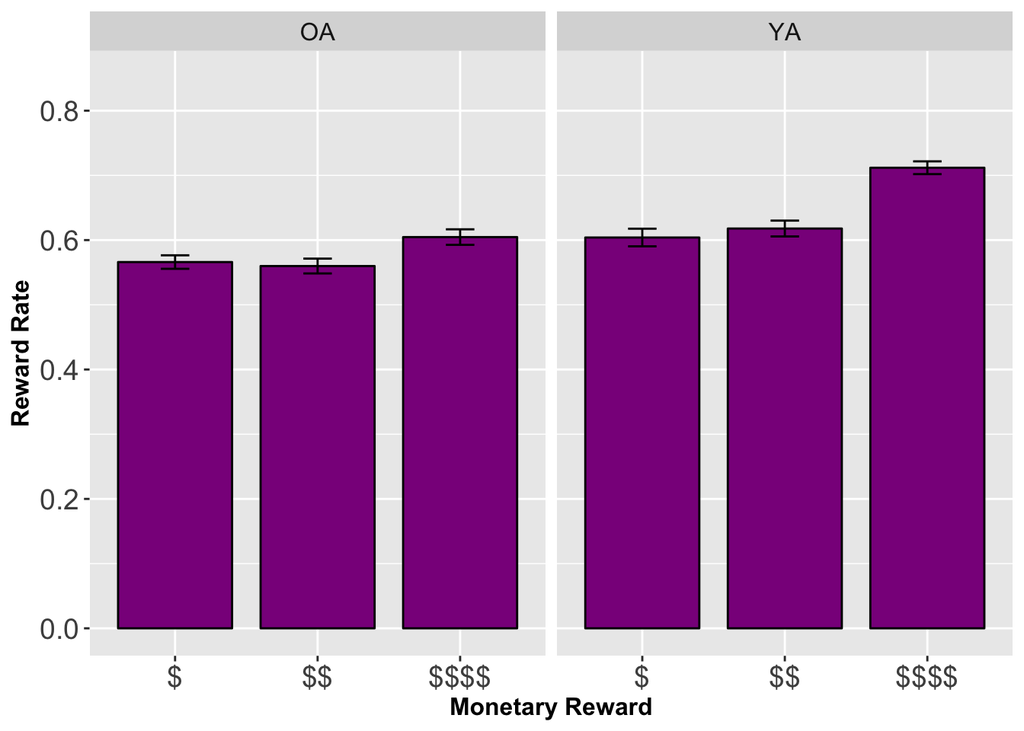

```r
p.RR.1<-ggplot(RR.sum, aes(x=money, y=meanRR)) +
  geom_bar(position=position_dodge(width=0.8), color="black",
           fill='darkmagenta', stat="identity", width=0.8) +
  geom_errorbar(position=position_dodge(width=0.8),
                aes(ymin=meanRR-se, ymax=meanRR+se), width=.2) +
  facet_grid(.~group) +
  xlab("Monetary Reward") + ylab("Reward Rate") +
  #ggtitle("Task Performance Across Money") +
  coord_cartesian(ylim=c(0,.85)) +
  scale_fill_discrete(name="Monetary Reward") +
  theme(#plot.title=element_text(size=22,face="bold", vjust=2),
        axis.title=element_text(size=12,face = "bold"),
        axis.text=element_text(size=14),
        legend.position="none",
        strip.text.x = element_text(size = 12))
p.RR.1
```

## Plot: mean reward rate by liquid type and age group

```r
RR.sum=summarySEwithin2(data=liq.means, measurevar = "meanRR", withinvars = c("liquid"),
                        betweenvars = c("group"), idvar = "subID")
pandoc.table(RR.sum)
```

```
##
## ------------------------------------------------------------------------------
##  group    liquid     N    meanRR   meanRRNormed     sd        se        ci
## ------- ----------- ---- -------- -------------- --------- --------- ---------
##   OA       juice     44   0.5859      0.6232      0.09714   0.01464   0.02953
##
##   OA      neutral    44   0.5724      0.6097      0.09889   0.01491   0.03006
##
##   OA     saltwater   44   0.5722      0.6095      0.1026    0.01546   0.03118
##
##   YA       juice     54   0.6966      0.6662      0.1032    0.01405   0.02817
##
##   YA      neutral    54   0.6576      0.6272      0.08538   0.01162   0.02331
##
##   YA     saltwater   54   0.5795      0.5491      0.1158    0.01576   0.03161
## ------------------------------------------------------------------------------
```

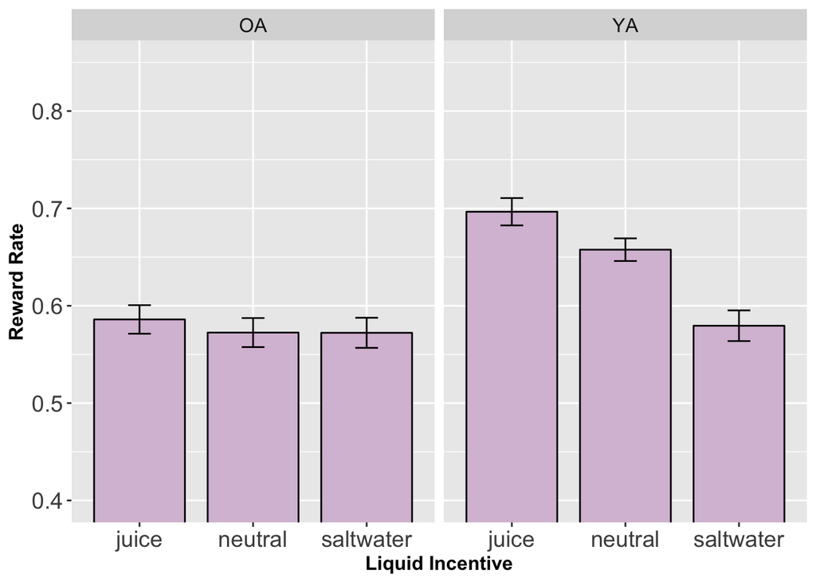

```r
p.RR.2<-ggplot(RR.sum, aes(x=liquid, y=meanRR)) +
  geom_bar(position=position_dodge(width=0.8), color="black", fill='thistle',
           stat="identity", width=0.8) +
  geom_errorbar(position=position_dodge(width=0.8),
                aes(ymin=meanRR-se, ymax=meanRR+se), width=.2) +
  facet_grid(.~group) +
  xlab("Liquid Incentive") + ylab("Reward Rate") +
  #ggtitle("Task Performance Across Liquid Type") +
  coord_cartesian(ylim=c(.4,.85)) +
  scale_fill_discrete(name="Monetary Reward") +
  theme(#plot.title=element_text(size=22,face="bold", vjust=2),
        axis.title=element_text(size=12,face = "bold"),
        axis.text=element_text(size=14),
        legend.position="none",
        strip.text.x = element_text(size = 12))
p.RR.2
```

## Plot: mean reward rate by money, liquid, and age group

```r
RR.sum=summarySEwithin2(data=incentive9.means, measurevar = "meanRR",
                        withinvars = c("money","liquid"), betweenvars = c("group"),
                        idvar = "subID")
pandoc.table(RR.sum)
```

```
##
## --------------------------------------------------------------------------------------
##  group   money    liquid     N    meanRR   meanRRNormed     sd        se        ci
## ------- ------- ----------- ---- -------- -------------- --------- --------- ---------
##   OA       $       juice     44   0.5788      0.6161      0.08623    0.013    0.02622
##
##   OA       $      neutral    44   0.5611      0.5984      0.1102    0.01662   0.03351
##
##   OA       $     saltwater   44   0.5582      0.5955      0.1138    0.01715   0.03459
##
##   OA      $$       juice     44   0.5682      0.6055      0.1097    0.01654   0.03335
##
##   OA      $$      neutral    44   0.5554      0.5927      0.1206    0.01818   0.03667
##
##   OA      $$     saltwater   44   0.5561      0.5934      0.1135    0.01711   0.03451
##
##   OA     $$$$      juice     44   0.6108      0.6481       0.127    0.01915   0.03861
##
##   OA     $$$$     neutral    44   0.6009      0.6381       0.104    0.01567   0.0316
##
##   OA     $$$$    saltwater   44   0.6023      0.6396      0.1281    0.01931   0.03895
##
##   YA       $       juice     54   0.6696      0.6392      0.09627   0.0131    0.02628
##
##   YA       $      neutral    54   0.6256      0.5952      0.1288    0.01753   0.03516
##
##   YA       $     saltwater   54   0.5168      0.4864      0.1689    0.02299   0.0461
##
##   YA      $$       juice     54   0.6678      0.6374      0.1336    0.01818   0.03645
##
##   YA      $$      neutral    54   0.6256      0.5952      0.1175     0.016    0.03208
##
##   YA      $$     saltwater   54   0.5602      0.5298      0.1301    0.0177    0.0355
##
##   YA     $$$$      juice     54   0.7523      0.7219      0.09888   0.01346   0.02699
##
##   YA     $$$$     neutral    54   0.7216      0.6913      0.09788   0.01332   0.02672
##
##   YA     $$$$    saltwater   54   0.6615      0.6311      0.1081    0.01471   0.0295
## --------------------------------------------------------------------------------------
```

```r
# first plot
p.RR.3<-ggplot(RR.sum, aes(x=liquid, y=meanRR, fill=money)) +
  geom_bar(position=position_dodge(width=0.8), color="black",
           stat="identity", width=0.8) +
  geom_errorbar(position=position_dodge(width=0.8),
                aes(ymin=meanRR-se, ymax=meanRR+se), width=.2) +
  xlab("Monetary Reward") + ylab("Reward Rate") +
  facet_grid(.~group) +
  #ggtitle("Punishment Avoidance Across Money and Liquid Type") +
  scale_fill_brewer(palette="Pastel2") +
  coord_cartesian(ylim=c(.4,.8)) +
  scale_fill_discrete(name="Monetary Reward") +
  theme(#plot.title=element_text(size=22,face="bold", vjust=2),
        axis.title=element_text(size=12,face = "bold"),
        axis.text=element_text(size=14),
        legend.position="right",
        strip.text.x = element_text(size = 12))
```

[output not shown]

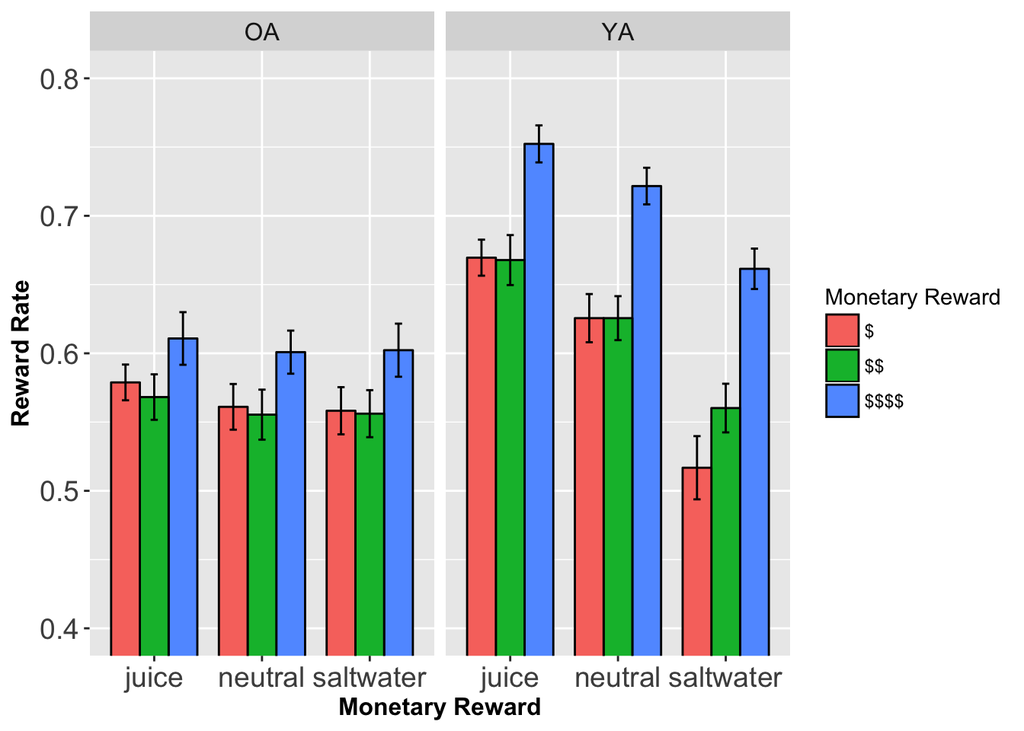

```r
p.RR.3
```

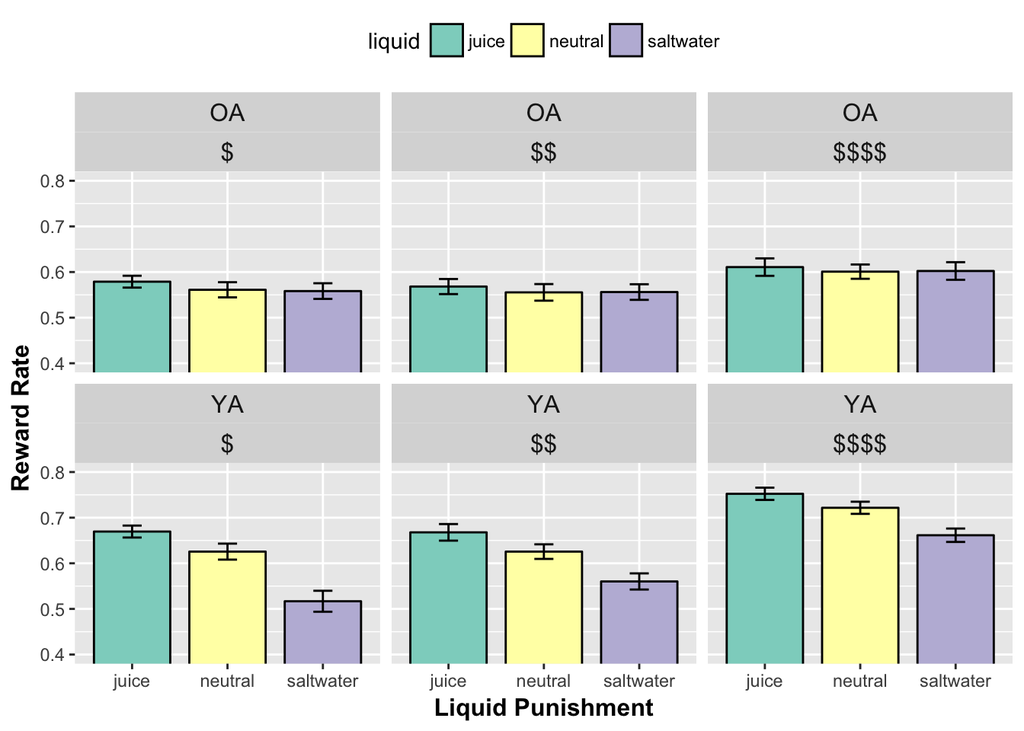

```r
# second plot
p.RR.4<-ggplot(RR.sum, aes(x=liquid, y=meanRR, fill=liquid)) +
  geom_bar(position=position_dodge(width=0.8),
           color="black", stat="identity", width=0.8) +
  geom_errorbar(position=position_dodge(width=0.8),
                aes(ymin=meanRR-se, ymax=meanRR+se), width=.2) +
  facet_wrap(group~money) +
  xlab("Liquid Punishment") + ylab("Reward Rate") +
  #ggtitle("Task Performance Across Money and Liquid Type") +
  coord_cartesian(ylim=c(.4,.8)) +
  scale_fill_brewer(palette="Set3") +
  #scale_fill_manual(name="Monetary Reward") +
  theme(#plot.title=element_text(size=22,face="bold", vjust=2),
        axis.title=element_text(size=12,face = "bold"),
        #axis.text=element_text(size=14),
        legend.position="top",
        strip.text.x = element_text(size = 12))
p.RR.4
```

```r
# ggplot(data = incentive9.means, mapping = aes(x = money, y = meanRR, col=subID, group=subID)) +
#   facet_grid(~liquid) +
#   geom_point() +
#   geom_line()
```

## Plot: mean reward rate by block and age group

```r
RR.sum=summarySEwithin2(data=liq.means, measurevar = "meanRR", withinvars = c("block"),
                        betweenvars = c("group"), idvar = "subID")
pandoc.table(RR.sum)
```

```
##
## ---------------------------------------------------------------------------
##  group   block   N    meanRR   meanRRNormed     sd         se        ci
## ------- ------- ---- -------- -------------- --------- ---------- ---------
##   OA       1     44   0.504       0.5413      0.08456   0.01275    0.02571
##
##   OA       2     44   0.5942      0.6315      0.05875   0.008856   0.01786
##
##   OA       3     44   0.6323      0.6696      0.07742   0.01167    0.02354
##
##   YA       1     54   0.6273      0.5969      0.1155    0.01572    0.03152
##
##   YA       2     54   0.6505      0.6201      0.1192    0.01621    0.03252
##
##   YA       3     54   0.6559      0.6255      0.1183     0.0161    0.03229
## ---------------------------------------------------------------------------
```

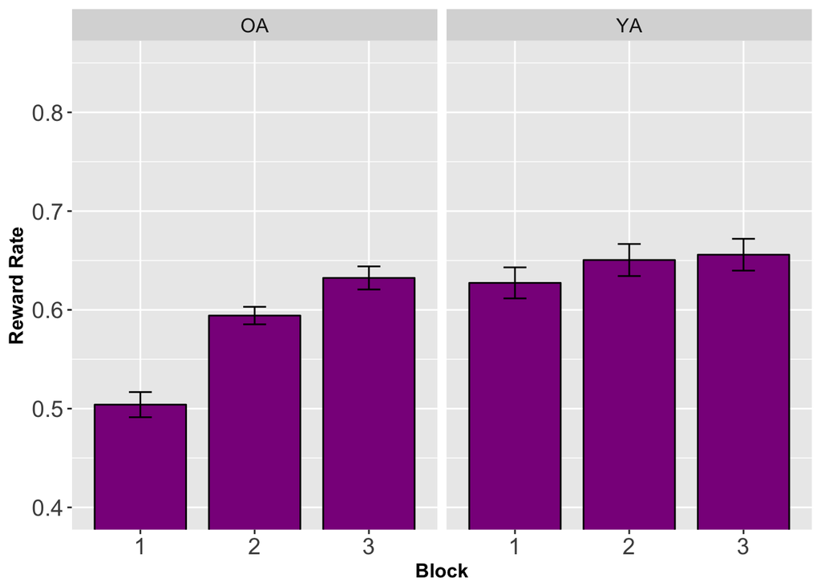

```r
p.RR.5<-ggplot(RR.sum, aes(x=block, y=meanRR)) +
  geom_bar(position=position_dodge(width=0.8), color="black",
           fill='darkmagenta',stat="identity", width=0.8) +
  geom_errorbar(position=position_dodge(width=0.8),
                aes(ymin=meanRR-se, ymax=meanRR+se), width=.2) +
  facet_grid(.~group) +
  xlab("Block") + ylab("Reward Rate") +
  #ggtitle("Task Performance Across Liquid Type") +
  coord_cartesian(ylim=c(.4,.85)) +
  scale_fill_discrete(name="Monetary Reward") +
  theme(#plot.title=element_text(size=22,face="bold", vjust=2),
        axis.title=element_text(size=12,face = "bold"),
        axis.text=element_text(size=14),
        legend.position="none",
        strip.text.x = element_text(size = 12))
p.RR.5
```

## Plot: mean reward rate by block, money, and age group

```r
RR.sum=summarySEwithin2(data=incentive9.means, measurevar = "meanRR",
                        withinvars = c("money","block"), betweenvars = c("group"),
                        idvar = "subID")
pandoc.table(RR.sum)
```

```
##
## ----------------------------------------------------------------------------------
##  group   money   block   N    meanRR   meanRRNormed     sd        se        ci
## ------- ------- ------- ---- -------- -------------- --------- --------- ---------
##   OA       $       1     44   0.5107      0.5479      0.1004    0.01514   0.03054
##
##   OA       $       2     44   0.5838      0.6211      0.09093   0.01371   0.02764
##
##   OA       $       3     44   0.6037      0.641       0.09451   0.01425   0.02873
##
##   OA      $$       1     44   0.4759      0.5131      0.1004    0.01514   0.03053
##
##   OA      $$       2     44   0.5952      0.6325      0.07892   0.0119    0.02399
##
##   OA      $$       3     44   0.6087      0.646       0.1047    0.01579   0.03185
##
##   OA     $$$$      1     44   0.5256      0.5629      0.1203    0.01813   0.03656
##
##   OA     $$$$      2     44   0.6037      0.641       0.08237   0.01242   0.02504
##
##   OA     $$$$      3     44   0.6847      0.722       0.08716   0.01314   0.0265
##
##   YA       $       1     54   0.6001      0.5697      0.1512    0.02058   0.04128
##
##   YA       $       2     54   0.6227      0.5923      0.1268    0.01726   0.03462
##
##   YA       $       3     54   0.5891      0.5587      0.1701    0.02315   0.04644
##
##   YA      $$       1     54   0.5903      0.5599      0.1216    0.01654   0.03318
##
##   YA      $$       2     54   0.6291      0.5987      0.1418    0.01929   0.03869
##
##   YA      $$       3     54   0.6343      0.6039      0.1383    0.01882   0.03774
##
##   YA     $$$$      1     54   0.6916      0.6612      0.1077    0.01465   0.02939
##
##   YA     $$$$      2     54   0.6997      0.6693      0.1197    0.01629   0.03267
##
##   YA     $$$$      3     54   0.7442      0.7138      0.09039   0.0123    0.02467
## ----------------------------------------------------------------------------------
```

```r
# first plot
p.RR.6<-ggplot(RR.sum, aes(x=block, y=meanRR, fill=money)) +
  geom_bar(position=position_dodge(width=0.8), color="black",
           stat="identity", width=0.8) +
  geom_errorbar(position=position_dodge(width=0.8),
                aes(ymin=meanRR-se, ymax=meanRR+se), width=.2) +
  xlab("Block") + ylab("Reward Rate") +
  facet_grid(.~group) +
  #ggtitle("Punishment Avoidance Across Money and Liquid Type") +
  scale_fill_brewer(palette="Pastel2") +
  coord_cartesian(ylim=c(.4,.8)) +
  scale_fill_discrete(name="Monetary Reward") +
  theme(#plot.title=element_text(size=22,face="bold", vjust=2),
        axis.title=element_text(size=12,face = "bold"),
        axis.text=element_text(size=14),
        legend.position="top",
        strip.text.x = element_text(size = 12))
```

[output not shown]

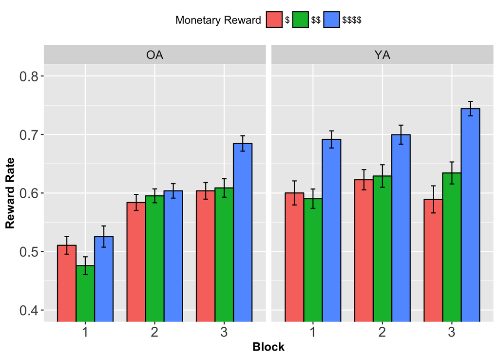

```r
p.RR.6
```

# Generalized Linear Mixed Effects Models of Reward Rate Effects by Condition (Money, Liquid, Block)

## Omnibus Incentive Motivation Effects by Age Group

## Reward Rate by Monetary Reward and Age Group

```r
# Monetary Reward Effect
m.RR.money <-glmer(formula = subRewarded ~ moneyCode * groupCode + (1+moneyCode|subID),
          data = incentive, family = binomial)
summary(m.RR.money)
```

```
## Generalized linear mixed model fit by maximum likelihood (Laplace
##   Approximation) [glmerMod]
##  Family: binomial  ( logit )
## Formula: subRewarded ~ moneyCode * groupCode + (1 + moneyCode | subID)
##    Data: incentive
##
##      AIC      BIC   logLik deviance df.resid
##  36155.7  36213.4 -18070.9  36141.7    28217
##
## Scaled residuals:
##     Min      1Q  Median      3Q     Max
## -2.5238 -1.0790  0.6020  0.7781  1.8581
##
## Random effects:
##  Groups Name        Variance Std.Dev. Corr
##  subID  (Intercept) 0.23811  0.4880
##         moneyCode   0.01212  0.1101   -0.16
## Number of obs: 28224, groups:  subID, 98
##
## Fixed effects:
##                     Estimate Std. Error z value Pr(>|z|)
## (Intercept)          0.63110    0.06859   9.201  < 2e-16 ***
## moneyCode            0.24920    0.02613   9.536  < 2e-16 ***
## groupCode           -0.30862    0.10215  -3.021  0.00252 **
## moneyCode:groupCode -0.16710    0.03835  -4.358 1.31e-05 ***
## ---
## Signif. codes:  0 '***' 0.001 '**' 0.01 '*' 0.05 '.' 0.1 ' ' 1
##
## Correlation of Fixed Effects:
##             (Intr) monyCd gropCd
## moneyCode   -0.075
## groupCode   -0.670  0.050
## mnyCd:grpCd  0.051 -0.681 -0.083
```

```r
# YA
m.RR.money.YA <-glmer(formula = subRewarded ~ moneyCode + (1+moneyCode|subID),
          data = subset(incentive,groupCode==0), family = binomial)
summary(m.RR.money.YA)
```

```
## Generalized linear mixed model fit by maximum likelihood (Laplace
##   Approximation) [glmerMod]
##  Family: binomial  ( logit )
## Formula: subRewarded ~ moneyCode + (1 + moneyCode | subID)
##    Data: subset(incentive, groupCode == 0)
##
##      AIC      BIC   logLik deviance df.resid
##  19409.8  19448.0  -9699.9  19399.8    15547
##
## Scaled residuals:
##     Min      1Q  Median      3Q     Max
## -2.5666 -1.0924  0.5779  0.7372  1.8434
##
## Random effects:
##  Groups Name        Variance Std.Dev. Corr
##  subID  (Intercept) 0.25574  0.5057
##         moneyCode   0.01781  0.1335   -0.05
## Number of obs: 15552, groups:  subID, 54
##
## Fixed effects:
##             Estimate Std. Error z value Pr(>|z|)
## (Intercept)  0.63220    0.07102   8.902   <2e-16 ***
## moneyCode    0.25050    0.02813   8.904   <2e-16 ***
## ---
## Signif. codes:  0 '***' 0.001 '**' 0.01 '*' 0.05 '.' 0.1 ' ' 1
##
## Correlation of Fixed Effects:
##           (Intr)
## moneyCode -0.019
```

```r
# Money $ (Low)
m.RR.1.money.YA.rew1 <-glmer(formula = subRewarded ~ liqCode + (1+liqCode|subID),
          data = subset(incentive, moneyCode==-1 & group=="YA"), family = binomial)
summary(m.RR.1.money.YA.rew1)
```

```
## Generalized linear mixed model fit by maximum likelihood (Laplace
##   Approximation) [glmerMod]
##  Family: binomial  ( logit )
## Formula: subRewarded ~ liqCode + (1 + liqCode | subID)
##    Data: subset(incentive, moneyCode == -1 & group == "YA")
##
##      AIC      BIC   logLik deviance df.resid
##   6587.7   6620.4  -3288.8   6577.7     5179
##
## Scaled residuals:
##     Min      1Q  Median      3Q     Max
## -2.3654 -1.0507  0.5789  0.7439  4.2355
##
## Random effects:
##  Groups Name        Variance Std.Dev. Corr
##  subID  (Intercept) 0.3254   0.5704
##         liqCode     0.1986   0.4456   -0.63
## Number of obs: 5184, groups:  subID, 54
##
## Fixed effects:
##             Estimate Std. Error z value Pr(>|z|)
## (Intercept)  0.44154    0.08337   5.296 1.18e-07 ***
## liqCode      0.35052    0.07137   4.911 9.05e-07 ***
## ---
## Signif. codes:  0 '***' 0.001 '**' 0.01 '*' 0.05 '.' 0.1 ' ' 1
##
## Correlation of Fixed Effects:
##         (Intr)
## liqCode -0.496
```

```r
# Money $$ (Medium)
m.RR.1.money.YA.rew2 <-glmer(formula = subRewarded ~ liqCode + (1+liqCode|subID),
          data = subset(incentive, moneyCode==0 & group=="YA"), family = binomial)
summary(m.RR.1.money.YA.rew2)
```

```
## Generalized linear mixed model fit by maximum likelihood (Laplace
##   Approximation) [glmerMod]
##  Family: binomial  ( logit )
## Formula: subRewarded ~ liqCode + (1 + liqCode | subID)
##    Data: subset(incentive, moneyCode == 0 & group == "YA")
##
##      AIC      BIC   logLik deviance df.resid
##   6596.9   6629.7  -3293.4   6586.9     5179
##
## Scaled residuals:
##     Min      1Q  Median      3Q     Max
## -2.7617 -1.0969  0.5829  0.7713  1.8903
##
## Random effects:
##  Groups Name        Variance Std.Dev. Corr
##  subID  (Intercept) 0.2920   0.5404
##         liqCode     0.2091   0.4573   -0.27
## Number of obs: 5184, groups:  subID, 54
##
## Fixed effects:
##             Estimate Std. Error z value Pr(>|z|)
## (Intercept)  0.51405    0.07959   6.459 1.05e-10 ***
## liqCode      0.25842    0.07272   3.554  0.00038 ***
## ---
## Signif. codes:  0 '***' 0.001 '**' 0.01 '*' 0.05 '.' 0.1 ' ' 1
##
## Correlation of Fixed Effects:
##         (Intr)
## liqCode -0.206
```

```r
# Money $$$$ (High)
m.RR.1.money.YA.rew4 <-glmer(formula = subRewarded ~ liqCode + (1+liqCode|subID),
          data = subset(incentive, moneyCode==1 & group=="YA"), family = binomial)
summary(m.RR.1.money.YA.rew4)
```

```
## Generalized linear mixed model fit by maximum likelihood (Laplace
##   Approximation) [glmerMod]
##  Family: binomial  ( logit )
## Formula: subRewarded ~ liqCode + (1 + liqCode | subID)
##    Data: subset(incentive, moneyCode == 1 & group == "YA")
##
##      AIC      BIC   logLik deviance df.resid
##   6001.1   6033.9  -2995.5   5991.1     5179
##
## Scaled residuals:
##     Min      1Q  Median      3Q     Max
## -2.8882 -1.0569  0.5039  0.6243  2.1198
##
## Random effects:
##  Groups Name        Variance Std.Dev. Corr
##  subID  (Intercept) 0.28346  0.5324
##         liqCode     0.07369  0.2715   -0.29
## Number of obs: 5184, groups:  subID, 54
##
## Fixed effects:
##             Estimate Std. Error z value Pr(>|z|)
## (Intercept)  0.96984    0.07949  12.201  < 2e-16 ***
## liqCode      0.22756    0.05450   4.175 2.97e-05 ***
## ---
## Signif. codes:  0 '***' 0.001 '**' 0.01 '*' 0.05 '.' 0.1 ' ' 1
##
## Correlation of Fixed Effects:
##         (Intr)
## liqCode -0.157
```

```r
# OA
m.RR.money.OA <-glmer(formula = subRewarded ~ moneyCode + (1+moneyCode|subID),
          data = subset(incentive,group=="OA"), family = binomial)
summary(m.RR.money.OA)
```

```
## Generalized linear mixed model fit by maximum likelihood (Laplace
##   Approximation) [glmerMod]
##  Family: binomial  ( logit )
## Formula: subRewarded ~ moneyCode + (1 + moneyCode | subID)
##    Data: subset(incentive, group == "OA")
##
##      AIC      BIC   logLik deviance df.resid
##  16749.7  16786.9  -8369.8  16739.7    12667
##
## Scaled residuals:
##     Min      1Q  Median      3Q     Max
## -1.7980 -1.0783  0.6617  0.8247  1.7064
##
## Random effects:
##  Groups Name        Variance Std.Dev. Corr
##  subID  (Intercept) 0.217087 0.46593
##         moneyCode   0.005865 0.07659  -0.39
## Number of obs: 12672, groups:  subID, 44
##
## Fixed effects:
##             Estimate Std. Error z value Pr(>|z|)
## (Intercept)  0.32200    0.07264   4.433 9.29e-06 ***
## moneyCode    0.08181    0.02542   3.218  0.00129 **
## ---
## Signif. codes:  0 '***' 0.001 '**' 0.01 '*' 0.05 '.' 0.1 ' ' 1
##
## Correlation of Fixed Effects:
##           (Intr)
## moneyCode -0.171
```

```r
# Money $ (Low)
m.RR.money.OA.rew1 <-glmer(formula = subRewarded ~ liqCode + (1+liqCode|subID),
          data = subset(incentive, moneyCode==-1 & group=="OA"), family = binomial)
summary(m.RR.money.OA.rew1)
```

```
## Generalized linear mixed model fit by maximum likelihood (Laplace
##   Approximation) [glmerMod]
##  Family: binomial  ( logit )
## Formula: subRewarded ~ liqCode + (1 + liqCode | subID)
##    Data: subset(incentive, moneyCode == -1 & group == "OA")
##
##      AIC      BIC   logLik deviance df.resid
##   5613.2   5645.0  -2801.6   5603.2     4219
##
## Scaled residuals:
##     Min      1Q  Median      3Q     Max
## -2.0686 -1.0212  0.6134  0.8213  1.7884
##
## Random effects:
##  Groups Name        Variance Std.Dev. Corr
##  subID  (Intercept) 0.27474  0.5242
##         liqCode     0.03455  0.1859   -0.19
## Number of obs: 4224, groups:  subID, 44
##
## Fixed effects:
##             Estimate Std. Error z value Pr(>|z|)
## (Intercept)  0.28263    0.08535   3.312 0.000928 ***
## liqCode      0.04306    0.04841   0.889 0.373801
## ---
## Signif. codes:  0 '***' 0.001 '**' 0.01 '*' 0.05 '.' 0.1 ' ' 1
##
## Correlation of Fixed Effects:
##         (Intr)
## liqCode -0.105
```

```r
# Money $$ (Medium)
m.RR.money.OA.rew2 <-glmer(formula = subRewarded ~ liqCode + (1+liqCode|subID),
          data = subset(incentive, moneyCode==0 & group=="OA"), family = binomial)
summary(m.RR.money.OA.rew2)
```

```
## Generalized linear mixed model fit by maximum likelihood (Laplace
##   Approximation) [glmerMod]
##  Family: binomial  ( logit )
## Formula: subRewarded ~ liqCode + (1 + liqCode | subID)
##    Data: subset(incentive, moneyCode == 0 & group == "OA")
##
##      AIC      BIC   logLik deviance df.resid
##   5683.8   5715.5  -2836.9   5673.8     4219
##
## Scaled residuals:
##     Min      1Q  Median      3Q     Max
## -1.6978 -1.0598  0.6628  0.8577  1.4982
##
## Random effects:
##  Groups Name        Variance Std.Dev. Corr
##  subID  (Intercept) 0.17846  0.4224
##         liqCode     0.08255  0.2873   0.11
## Number of obs: 4224, groups:  subID, 44
##
## Fixed effects:
##             Estimate Std. Error z value Pr(>|z|)
## (Intercept)  0.25157    0.07123   3.532 0.000413 ***
## liqCode      0.02655    0.05841   0.455 0.649383
## ---
## Signif. codes:  0 '***' 0.001 '**' 0.01 '*' 0.05 '.' 0.1 ' ' 1
##
## Correlation of Fixed Effects:
##         (Intr)
## liqCode 0.077
```

```r
# Money $$$$ (High)
m.RR.money.OA.rew4 <-glmer(formula = subRewarded ~ liqCode + (1+liqCode|subID),
          data = subset(incentive, moneyCode==1 & group=="OA"), family = binomial)
summary(m.RR.money.OA.rew4)
```

```
## Generalized linear mixed model fit by maximum likelihood (Laplace
##   Approximation) [glmerMod]
##  Family: binomial  ( logit )
## Formula: subRewarded ~ liqCode + (1 + liqCode | subID)
##    Data: subset(incentive, moneyCode == 1 & group == "OA")
##
##      AIC      BIC   logLik deviance df.resid
##   5524.0   5555.8  -2757.0   5514.0     4219
##
## Scaled residuals:
##     Min      1Q  Median      3Q     Max
## -2.0242 -1.1063  0.6281  0.7872  1.8613
##
## Random effects:
##  Groups Name        Variance Std.Dev. Corr
##  subID  (Intercept) 0.23731  0.4871
##         liqCode     0.07191  0.2682   -0.07
## Number of obs: 4224, groups:  subID, 44
##
## Fixed effects:
##             Estimate Std. Error z value Pr(>|z|)
## (Intercept)  0.44708    0.08037   5.563 2.65e-08 ***
## liqCode      0.01973    0.05690   0.347    0.729
## ---
## Signif. codes:  0 '***' 0.001 '**' 0.01 '*' 0.05 '.' 0.1 ' ' 1
##
## Correlation of Fixed Effects:
##         (Intr)
## liqCode -0.046
```

## Reward Rate by Liquid and Age Group

```r
# Monetary Reward Effect
m.RR.liquid <-glmer(formula = subRewarded ~ moneyCode * liqCode * groupCode + (1+moneyCode|subID),
          data = incentive, family = binomial)
summary(m.RR.liquid)
```

```
## Generalized linear mixed model fit by maximum likelihood (Laplace
##   Approximation) [glmerMod]
##  Family: binomial  ( logit )
## Formula: subRewarded ~ moneyCode * liqCode * groupCode + (1 + moneyCode |
##     subID)
##    Data: incentive
##
##      AIC      BIC   logLik deviance df.resid
##  35990.9  36081.6 -17984.4  35968.9    28213
##
## Scaled residuals:
##     Min      1Q  Median      3Q     Max
## -2.8313 -1.0738  0.5838  0.7798  2.2101
##
## Random effects:
##  Groups Name        Variance Std.Dev. Corr
##  subID  (Intercept) 0.24148  0.4914
##         moneyCode   0.01248  0.1117   -0.17
## Number of obs: 28224, groups:  subID, 98
##
## Fixed effects:
##                             Estimate Std. Error z value Pr(>|z|)
## (Intercept)                  0.63776    0.06914   9.225  < 2e-16 ***
## moneyCode                    0.24914    0.02639   9.442  < 2e-16 ***
## liqCode                      0.27271    0.02145  12.716  < 2e-16 ***
## groupCode                   -0.31522    0.10297  -3.061   0.0022 **
## moneyCode:liqCode           -0.05632    0.02632  -2.140   0.0324 *
## moneyCode:groupCode         -0.16711    0.03862  -4.327 1.51e-05 ***
## liqCode:groupCode           -0.24308    0.03117  -7.799 6.25e-15 ***
## moneyCode:liqCode:groupCode  0.04347    0.03822   1.137   0.2554
## ---
## Signif. codes:  0 '***' 0.001 '**' 0.01 '*' 0.05 '.' 0.1 ' ' 1
##
## Correlation of Fixed Effects:
##             (Intr) monyCd liqCod gropCd mnyCd:lC mnyCd:gC lqCd:C
## moneyCode   -0.083
## liqCode      0.015  0.010
## groupCode   -0.671  0.056 -0.010
## monyCd:lqCd  0.003  0.047  0.046 -0.002
## mnyCd:grpCd  0.057 -0.682 -0.007 -0.090 -0.032
## liqCd:grpCd -0.011 -0.007 -0.688  0.008 -0.031    0.004
## mnyCd:lqC:C -0.002 -0.032 -0.031  0.001 -0.688    0.023    0.025
```

```r
# YA
m.RR.liquid.YA <-glmer(formula = subRewarded ~ moneyCode * liqCode + (1+moneyCode|subID),
          data = subset(incentive,group=="YA"), family = binomial)
summary(m.RR.liquid.YA)
```

```
## Generalized linear mixed model fit by maximum likelihood (Laplace
##   Approximation) [glmerMod]
##  Family: binomial  ( logit )
## Formula: subRewarded ~ moneyCode * liqCode + (1 + moneyCode | subID)
##    Data: subset(incentive, group == "YA")
##
##      AIC      BIC   logLik deviance df.resid
##  19242.7  19296.3  -9614.4  19228.7    15545
##
## Scaled residuals:
##     Min      1Q  Median      3Q     Max
## -2.8790 -1.0750  0.5596  0.7286  2.1966
##
## Random effects:
##  Groups Name        Variance Std.Dev. Corr
##  subID  (Intercept) 0.26183  0.5117
##         moneyCode   0.01856  0.1362   -0.07
## Number of obs: 15552, groups:  subID, 54
##
## Fixed effects:
##                   Estimate Std. Error z value Pr(>|z|)
## (Intercept)        0.63889    0.07183   8.894   <2e-16 ***
## moneyCode          0.25040    0.02850   8.786   <2e-16 ***
## liqCode            0.27303    0.02146  12.721   <2e-16 ***
## moneyCode:liqCode -0.05605    0.02635  -2.127   0.0334 *
## ---
## Signif. codes:  0 '***' 0.001 '**' 0.01 '*' 0.05 '.' 0.1 ' ' 1
##
## Correlation of Fixed Effects:
##             (Intr) monyCd liqCod
## moneyCode   -0.032
## liqCode      0.015  0.009
## monyCd:lqCd  0.003  0.045  0.047
```

```r
# Juice
m.RR.liquid.YA.juice <-glmer(formula = subRewarded ~ moneyCode + (1+moneyCode|subID),
          data = subset(incentive, liqCode==1 & group=="YA"), family = binomial)
summary(m.RR.liquid.YA.juice)
```

```
## Generalized linear mixed model fit by maximum likelihood (Laplace
##   Approximation) [glmerMod]
##  Family: binomial  ( logit )
## Formula: subRewarded ~ moneyCode + (1 + moneyCode | subID)
##    Data: subset(incentive, liqCode == 1 & group == "YA")
##
##      AIC      BIC   logLik deviance df.resid
##   6165.0   6197.8  -3077.5   6155.0     5179
##
## Scaled residuals:
##     Min      1Q  Median      3Q     Max
## -3.8038 -1.1394  0.5251  0.6816  1.3090
##
## Random effects:
##  Groups Name        Variance Std.Dev. Corr
##  subID  (Intercept) 0.285187 0.5340
##         moneyCode   0.003387 0.0582   1.00
## Number of obs: 5184, groups:  subID, 54
##
## Fixed effects:
##             Estimate Std. Error z value Pr(>|z|)
## (Intercept)  0.89090    0.07944  11.215  < 2e-16 ***
## moneyCode    0.21858    0.03990   5.478  4.3e-08 ***
## ---
## Signif. codes:  0 '***' 0.001 '**' 0.01 '*' 0.05 '.' 0.1 ' ' 1
##
## Correlation of Fixed Effects:
##           (Intr)
## moneyCode 0.218
## convergence code: 0
## Model failed to converge with max|grad| = 0.00284983 (tol = 0.001, component 1)
```

```r
# Neutral
m.RR.money.YA.neut <-glmer(formula = subRewarded ~ moneyCode + (1+moneyCode|subID),
          data = subset(incentive, liqCode==0 & group=="YA"), family = binomial)
summary(m.RR.money.YA.neut)
```

```
## Generalized linear mixed model fit by maximum likelihood (Laplace
##   Approximation) [glmerMod]
##  Family: binomial  ( logit )
## Formula: subRewarded ~ moneyCode + (1 + moneyCode | subID)
##    Data: subset(incentive, liqCode == 0 & group == "YA")
##
##      AIC      BIC   logLik deviance df.resid
##   6357.7   6390.5  -3173.9   6347.7     5179
##
## Scaled residuals:
##     Min      1Q  Median      3Q     Max
## -2.3830 -1.0525  0.5665  0.6802  3.1229
##
## Random effects:
##  Groups Name        Variance Std.Dev. Corr
##  subID  (Intercept) 0.36088  0.6007
##         moneyCode   0.08514  0.2918   -0.47
## Number of obs: 5184, groups:  subID, 54
##
## Fixed effects:
##             Estimate Std. Error z value Pr(>|z|)
## (Intercept)  0.69152    0.08748   7.905 2.67e-15 ***
## moneyCode    0.23003    0.05506   4.178 2.94e-05 ***
## ---
## Signif. codes:  0 '***' 0.001 '**' 0.01 '*' 0.05 '.' 0.1 ' ' 1
##
## Correlation of Fixed Effects:
##           (Intr)
## moneyCode -0.308
```

```r
# Saltwater
m.RR.money.YA.salt <-glmer(formula = subRewarded ~ moneyCode + (1+moneyCode|subID),
          data = subset(incentive, liqCode==-1 & group=="YA"), family = binomial)
summary(m.RR.money.YA.salt)
```

```
## Generalized linear mixed model fit by maximum likelihood (Laplace
##   Approximation) [glmerMod]
##  Family: binomial  ( logit )
## Formula: subRewarded ~ moneyCode + (1 + moneyCode | subID)
##    Data: subset(incentive, liqCode == -1 & group == "YA")
##
##      AIC      BIC   logLik deviance df.resid
##   6495.0   6527.7  -3242.5   6485.0     5179
##
## Scaled residuals:
##     Min      1Q  Median      3Q     Max
## -2.4393 -0.9915  0.5251  0.7704  4.9680
##
## Random effects:
##  Groups Name        Variance Std.Dev. Corr
##  subID  (Intercept) 0.6386   0.7992
##         moneyCode   0.1081   0.3289   -0.37
## Number of obs: 5184, groups:  subID, 54
##
## Fixed effects:
##             Estimate Std. Error z value Pr(>|z|)
## (Intercept)  0.33243    0.11311   2.939  0.00329 **
## moneyCode    0.34037    0.05864   5.804 6.47e-09 ***
## ---
## Signif. codes:  0 '***' 0.001 '**' 0.01 '*' 0.05 '.' 0.1 ' ' 1
##
## Correlation of Fixed Effects:
##           (Intr)
## moneyCode -0.272
```

```r
# OA
m.RR.liquid.OA <-glmer(formula = subRewarded ~ moneyCode * liqCode + (1+moneyCode|subID),
          data = subset(incentive,groupCode==1), family = binomial)
summary(m.RR.liquid.OA)
```

```
## Generalized linear mixed model fit by maximum likelihood (Laplace
##   Approximation) [glmerMod]
##  Family: binomial  ( logit )
## Formula: subRewarded ~ moneyCode * liqCode + (1 + moneyCode | subID)
##    Data: subset(incentive, groupCode == 1)
##
##      AIC      BIC   logLik deviance df.resid
##  16751.8  16803.9  -8368.9  16737.8    12665
##
## Scaled residuals:
##     Min      1Q  Median      3Q     Max
## -1.8131 -1.0780  0.6615  0.8277  1.7432
##
## Random effects:
##  Groups Name        Variance Std.Dev. Corr
##  subID  (Intercept) 0.217160 0.46600
##         moneyCode   0.005874 0.07664  -0.39
## Number of obs: 12672, groups:  subID, 44
##
## Fixed effects:
##                   Estimate Std. Error z value Pr(>|z|)
## (Intercept)        0.32205    0.07264   4.433 9.28e-06 ***
## moneyCode          0.08178    0.02542   3.217   0.0013 **
## liqCode            0.02959    0.02260   1.309   0.1905
## moneyCode:liqCode -0.01287    0.02770  -0.465   0.6422
## ---
## Signif. codes:  0 '***' 0.001 '**' 0.01 '*' 0.05 '.' 0.1 ' ' 1
##
## Correlation of Fixed Effects:
##             (Intr) monyCd liqCod
## moneyCode   -0.171
## liqCode      0.001  0.000
## monyCd:lqCd  0.000  0.003  0.005
```

```r
# Juice
m.RR.liquid.OA.juice <-glmer(formula = subRewarded ~ moneyCode + (1+moneyCode|subID),
          data = subset(incentive, liqCode==1 & group=="OA"), family = binomial)
summary(m.RR.liquid.OA.juice)
```

```
## Generalized linear mixed model fit by maximum likelihood (Laplace
##   Approximation) [glmerMod]
##  Family: binomial  ( logit )
## Formula: subRewarded ~ moneyCode + (1 + moneyCode | subID)
##    Data: subset(incentive, liqCode == 1 & group == "OA")
##
##      AIC      BIC   logLik deviance df.resid
##   5548.4   5580.1  -2769.2   5538.4     4219
##
## Scaled residuals:
##     Min      1Q  Median      3Q     Max
## -2.1802 -1.0283  0.6101  0.8139  1.7116
##
## Random effects:
##  Groups Name        Variance  Std.Dev. Corr
##  subID  (Intercept) 0.2975482 0.54548
##         moneyCode   0.0009153 0.03025  1.00
## Number of obs: 4224, groups:  subID, 44
##
## Fixed effects:
##             Estimate Std. Error z value Pr(>|z|)
## (Intercept)  0.36982    0.08843   4.182 2.89e-05 ***
## moneyCode    0.07264    0.03995   1.818    0.069 .
## ---
## Signif. codes:  0 '***' 0.001 '**' 0.01 '*' 0.05 '.' 0.1 ' ' 1
##
## Correlation of Fixed Effects:
##           (Intr)
## moneyCode 0.113
```

```r
# Neutral
m.RR.money.OA.neut <-glmer(formula = subRewarded ~ moneyCode + (1+moneyCode|subID),
          data = subset(incentive, liqCode==0 & group=="OA"), family = binomial)
summary(m.RR.money.OA.neut)
```

```
## Generalized linear mixed model fit by maximum likelihood (Laplace
##   Approximation) [glmerMod]
##  Family: binomial  ( logit )
## Formula: subRewarded ~ moneyCode + (1 + moneyCode | subID)
##    Data: subset(incentive, liqCode == 0 & group == "OA")
##
##      AIC      BIC   logLik deviance df.resid
##   5531.8   5563.6  -2760.9   5521.8     4219
##
## Scaled residuals:
##     Min      1Q  Median      3Q     Max
## -2.2211 -1.0019  0.6106  0.8056  1.8021
##
## Random effects:
##  Groups Name        Variance Std.Dev. Corr
##  subID  (Intercept) 0.367186 0.60596
##         moneyCode   0.003483 0.05902  -0.56
## Number of obs: 4224, groups:  subID, 44
##
## Fixed effects:
##             Estimate Std. Error z value Pr(>|z|)
## (Intercept)  0.31532    0.09702   3.250  0.00115 **
## moneyCode    0.08602    0.04081   2.108  0.03505 *
## ---
## Signif. codes:  0 '***' 0.001 '**' 0.01 '*' 0.05 '.' 0.1 ' ' 1
##
## Correlation of Fixed Effects:
##           (Intr)
## moneyCode -0.113
```

```r
# Saltwater
m.RR.money.OA.salt <-glmer(formula = subRewarded ~ moneyCode + (1+moneyCode|subID),
          data = subset(incentive, liqCode==-1 & group=="OA"), family = binomial)
summary(m.RR.money.OA.salt)
```

```
## Generalized linear mixed model fit by maximum likelihood (Laplace
##   Approximation) [glmerMod]
##  Family: binomial  ( logit )
## Formula: subRewarded ~ moneyCode + (1 + moneyCode | subID)
##    Data: subset(incentive, liqCode == -1 & group == "OA")
##
##      AIC      BIC   logLik deviance df.resid
##   5572.3   5604.1  -2781.2   5562.3     4219
##
## Scaled residuals:
##     Min      1Q  Median      3Q     Max
## -1.8872 -1.0768  0.6257  0.8300  1.9767
##
## Random effects:
##  Groups Name        Variance Std.Dev. Corr
##  subID  (Intercept) 0.307252 0.55430
##         moneyCode   0.006367 0.07979  -0.13
## Number of obs: 4224, groups:  subID, 44
##
## Fixed effects:
##             Estimate Std. Error z value Pr(>|z|)
## (Intercept)  0.30555    0.08962   3.410 0.000651 ***
## moneyCode    0.09577    0.04133   2.318 0.020473 *
## ---
## Signif. codes:  0 '***' 0.001 '**' 0.01 '*' 0.05 '.' 0.1 ' ' 1
##
## Correlation of Fixed Effects:
##           (Intr)
## moneyCode -0.032
```

## Reward Rate by Block and Age Group

```r
# Monetary Reward and Block Effect
m.RR.block <-glmer(formula = subRewarded ~ moneyCode * blockCode * groupCode + (1+moneyCode|subID),
          data = incentive, family = binomial)
summary(m.RR.block)
```

```
## Generalized linear mixed model fit by maximum likelihood (Laplace
##   Approximation) [glmerMod]
##  Family: binomial  ( logit )
## Formula:
## subRewarded ~ moneyCode * blockCode * groupCode + (1 + moneyCode |
##     subID)
##    Data: incentive
##
##      AIC      BIC   logLik deviance df.resid
##  35986.6  36077.3 -17982.3  35964.6    28213
##
## Scaled residuals:
##     Min      1Q  Median      3Q     Max
## -2.7313 -1.0624  0.5843  0.7755  1.8687
##
## Random effects:
##  Groups Name        Variance Std.Dev. Corr
##  subID  (Intercept) 0.24110  0.4910
##         moneyCode   0.01234  0.1111   -0.14
## Number of obs: 28224, groups:  subID, 98
##
## Fixed effects:
##                                Estimate Std. Error z value Pr(>|z|)
## (Intercept)                    0.632341   0.069054   9.157  < 2e-16 ***
## moneyCode                      0.250767   0.026235   9.558  < 2e-16 ***
## blockCode                      0.070045   0.021255   3.295 0.000983 ***
## groupCode                     -0.305320   0.102907  -2.967 0.003008 **
## moneyCode:blockCode            0.079152   0.026089   3.034 0.002414 **
## moneyCode:groupCode           -0.165484   0.038578  -4.290 1.79e-05 ***
## blockCode:groupCode            0.209924   0.031216   6.725 1.76e-11 ***
## moneyCode:blockCode:groupCode -0.003968   0.038277  -0.104 0.917431
## ---
## Signif. codes:  0 '***' 0.001 '**' 0.01 '*' 0.05 '.' 0.1 ' ' 1
##
## Correlation of Fixed Effects:
##             (Intr) monyCd blckCd gropCd mnyCd:bC mnyCd:gC blcC:C
## moneyCode   -0.065
## blockCode    0.006  0.017
## groupCode   -0.671  0.044 -0.004
## mnyCd:blckC  0.005  0.019  0.054 -0.004
## mnyCd:grpCd  0.044 -0.679 -0.011 -0.072 -0.013
## blckCd:grpC -0.004 -0.011 -0.681  0.007 -0.037    0.014
## mnyCd:blC:C -0.003 -0.012 -0.037  0.004 -0.681    0.024    0.033
```

```r
# YA
m.RR.block.YA <-glmer(formula = subRewarded ~ moneyCode * blockCode + (1+moneyCode|subID),
          data = subset(incentive,groupCode==0), family = binomial)
summary(m.RR.block.YA)
```

```
## Generalized linear mixed model fit by maximum likelihood (Laplace
##   Approximation) [glmerMod]
##  Family: binomial  ( logit )
## Formula: subRewarded ~ moneyCode * blockCode + (1 + moneyCode | subID)
##    Data: subset(incentive, groupCode == 0)
##
##      AIC      BIC   logLik deviance df.resid
##  19394.6  19448.2  -9690.3  19380.6    15545
##
## Scaled residuals:
##     Min      1Q  Median      3Q     Max
## -2.7734 -1.0923  0.5706  0.7359  1.8518
##
## Random effects:
##  Groups Name        Variance Std.Dev. Corr
##  subID  (Intercept) 0.25641  0.5064
##         moneyCode   0.01789  0.1337   -0.04
## Number of obs: 15552, groups:  subID, 54
##
## Fixed effects:
##                     Estimate Std. Error z value Pr(>|z|)
## (Intercept)          0.63335    0.07110   8.907  < 2e-16 ***
## moneyCode            0.25195    0.02818   8.941  < 2e-16 ***
## blockCode            0.07020    0.02127   3.301 0.000964 ***
## moneyCode:blockCode  0.07935    0.02611   3.039 0.002371 **
## ---
## Signif. codes:  0 '***' 0.001 '**' 0.01 '*' 0.05 '.' 0.1 ' ' 1
##
## Correlation of Fixed Effects:
##             (Intr) monyCd blckCd
## moneyCode   -0.014
## blockCode    0.005  0.016
## mnyCd:blckC  0.005  0.018  0.055
```

```r
#block1
m.RR.block1.YA <-glmer(formula = subRewarded ~ moneyCode + (1+moneyCode|subID),
          data = subset(incentive,blockCode==-1 & group=="YA"), family = binomial)
summary(m.RR.block1.YA)
```

```
## Generalized linear mixed model fit by maximum likelihood (Laplace
##   Approximation) [glmerMod]
##  Family: binomial  ( logit )
## Formula: subRewarded ~ moneyCode + (1 + moneyCode | subID)
##    Data: subset(incentive, blockCode == -1 & group == "YA")
##
##      AIC      BIC   logLik deviance df.resid
##   6697.7   6730.5  -3343.9   6687.7     5179
##
## Scaled residuals:
##     Min      1Q  Median      3Q     Max
## -1.8994 -1.1374  0.6240  0.7542  1.4505
##
## Random effects:
##  Groups Name        Variance Std.Dev. Corr
##  subID  (Intercept) 0.17844  0.4224
##         moneyCode   0.03197  0.1788   -0.36
## Number of obs: 5184, groups:  subID, 54
##
## Fixed effects:
##             Estimate Std. Error z value Pr(>|z|)
## (Intercept)  0.54528    0.06469   8.429  < 2e-16 ***
## moneyCode    0.20058    0.04380   4.580 4.66e-06 ***
## ---
## Signif. codes:  0 '***' 0.001 '**' 0.01 '*' 0.05 '.' 0.1 ' ' 1
##
## Correlation of Fixed Effects:
##           (Intr)
## moneyCode -0.162
```

```r
#block2
m.RR.block2.YA <-glmer(formula = subRewarded ~ moneyCode + (1+moneyCode|subID),
          data = subset(incentive,blockCode==0 & group=="YA"), family = binomial)
summary(m.RR.block2.YA)
```

```
## Generalized linear mixed model fit by maximum likelihood (Laplace
##   Approximation) [glmerMod]
##  Family: binomial  ( logit )
## Formula: subRewarded ~ moneyCode + (1 + moneyCode | subID)
##    Data: subset(incentive, blockCode == 0 & group == "YA")
##
##      AIC      BIC   logLik deviance df.resid
##   6229.3   6262.1  -3109.6   6219.3     5179
##
## Scaled residuals:
##     Min      1Q  Median      3Q     Max
## -2.6500 -1.0624  0.5297  0.6758  4.0293
##
## Random effects:
##  Groups Name        Variance Std.Dev. Corr
##  subID  (Intercept) 0.63947  0.7997
##         moneyCode   0.03608  0.1899   -0.11
## Number of obs: 5184, groups:  subID, 54
##
## Fixed effects:
##             Estimate Std. Error z value Pr(>|z|)
## (Intercept)  0.66613    0.11341   5.873 4.27e-09 ***
## moneyCode    0.19179    0.04634   4.139 3.49e-05 ***
## ---
## Signif. codes:  0 '***' 0.001 '**' 0.01 '*' 0.05 '.' 0.1 ' ' 1
##
## Correlation of Fixed Effects:
##           (Intr)
## moneyCode -0.047
```

```r
#block3
m.RR.block3.YA <-glmer(formula = subRewarded ~ moneyCode + (1+moneyCode|subID),
          data = subset(incentive,blockCode==1 & group=="YA"), family = binomial)
summary(m.RR.block3.YA)
```

```
## Generalized linear mixed model fit by maximum likelihood (Laplace
##   Approximation) [glmerMod]
##  Family: binomial  ( logit )
## Formula: subRewarded ~ moneyCode + (1 + moneyCode | subID)
##    Data: subset(incentive, blockCode == 1 & group == "YA")
##
##      AIC      BIC   logLik deviance df.resid
##   6104.0   6136.8  -3047.0   6094.0     5179
##
## Scaled residuals:
##     Min      1Q  Median      3Q     Max
## -3.5600 -0.9055  0.5000  0.6544  3.8601
##
## Random effects:
##  Groups Name        Variance Std.Dev. Corr
##  subID  (Intercept) 0.63820  0.7989
##         moneyCode   0.09633  0.3104   -0.65
## Number of obs: 5184, groups:  subID, 54
##
## Fixed effects:
##             Estimate Std. Error z value Pr(>|z|)
## (Intercept)  0.70782    0.11351   6.236 4.50e-10 ***
## moneyCode    0.38442    0.05805   6.623 3.53e-11 ***
## ---
## Signif. codes:  0 '***' 0.001 '**' 0.01 '*' 0.05 '.' 0.1 ' ' 1
##
## Correlation of Fixed Effects:
##           (Intr)
## moneyCode -0.442
```

```r
# OA
m.RR.block.OA <-glmer(formula = subRewarded ~ moneyCode * blockCode + (1+moneyCode|subID),
          data = subset(incentive,groupCode==1), family = binomial)
summary(m.RR.block.OA)
```

```
## Generalized linear mixed model fit by maximum likelihood (Laplace
##   Approximation) [glmerMod]
##  Family: binomial  ( logit )
## Formula: subRewarded ~ moneyCode * blockCode + (1 + moneyCode | subID)
##    Data: subset(incentive, groupCode == 1)
##
##      AIC      BIC   logLik deviance df.resid
##  16595.9  16648.1  -8291.0  16581.9    12665
##
## Scaled residuals:
##     Min      1Q  Median      3Q     Max
## -2.1739 -1.0409  0.6219  0.8237  1.8971
##
## Random effects:
##  Groups Name        Variance Std.Dev. Corr
##  subID  (Intercept) 0.222787 0.47200
##         moneyCode   0.006143 0.07838  -0.35
## Number of obs: 12672, groups:  subID, 44
##
## Fixed effects:
##                     Estimate Std. Error z value Pr(>|z|)
## (Intercept)          0.32656    0.07356   4.440 9.01e-06 ***
## moneyCode            0.08502    0.02569   3.310 0.000934 ***
## blockCode            0.27950    0.02285  12.231  < 2e-16 ***
## moneyCode:blockCode  0.07459    0.02800   2.663 0.007735 **
## ---
## Signif. codes:  0 '***' 0.001 '**' 0.01 '*' 0.05 '.' 0.1 ' ' 1
##
## Correlation of Fixed Effects:
##             (Intr) monyCd blckCd
## moneyCode   -0.151
## blockCode    0.009  0.014
## mnyCd:blckC  0.004  0.033  0.014
```

```r
#block1
m.RR.block1.OA <-glmer(formula = subRewarded ~ moneyCode + (1+moneyCode|subID),
          data = subset(incentive,blockCode==-1 & group=="OA"), family = binomial)
summary(m.RR.block1.OA)
```

```
## Generalized linear mixed model fit by maximum likelihood (Laplace
##   Approximation) [glmerMod]
##  Family: binomial  ( logit )
## Formula: subRewarded ~ moneyCode + (1 + moneyCode | subID)
##    Data: subset(incentive, blockCode == -1 & group == "OA")
##
##      AIC      BIC   logLik deviance df.resid
##   5718.6   5750.3  -2854.3   5708.6     4219
##
## Scaled residuals:
##     Min      1Q  Median      3Q     Max
## -1.6126 -0.9654  0.6201  0.9182  1.9026
##
## Random effects:
##  Groups Name        Variance Std.Dev. Corr
##  subID  (Intercept) 0.236175 0.48598
##         moneyCode   0.003205 0.05661  -0.11
## Number of obs: 4224, groups:  subID, 44
##
## Fixed effects:
##             Estimate Std. Error z value Pr(>|z|)
## (Intercept)  0.01309    0.07983   0.164    0.870
## moneyCode    0.03149    0.03967   0.794    0.427
##
## Correlation of Fixed Effects:
##           (Intr)
## moneyCode -0.022
```

```r
#block2
m.RR.block2.OA <-glmer(formula = subRewarded ~ moneyCode + (1+moneyCode|subID),
          data = subset(incentive,blockCode==0 & group=="OA"), family = binomial)
summary(m.RR.block2.OA)
```

```
## Generalized linear mixed model fit by maximum likelihood (Laplace
##   Approximation) [glmerMod]
##  Family: binomial  ( logit )
## Formula: subRewarded ~ moneyCode + (1 + moneyCode | subID)
##    Data: subset(incentive, blockCode == 0 & group == "OA")
##
##      AIC      BIC   logLik deviance df.resid
##   5538.9   5570.7  -2764.5   5528.9     4219
##
## Scaled residuals:
##     Min      1Q  Median      3Q     Max
## -2.2817 -1.0905  0.6408  0.8049  1.7943
##
## Random effects:
##  Groups Name        Variance Std.Dev. Corr
##  subID  (Intercept) 0.275514 0.52489
##         moneyCode   0.004809 0.06935  -1.00
## Number of obs: 4224, groups:  subID, 44
##
## Fixed effects:
##             Estimate Std. Error z value Pr(>|z|)
## (Intercept)  0.40171    0.08554   4.696 2.65e-06 ***
## moneyCode    0.03930    0.04105   0.957    0.338
## ---
## Signif. codes:  0 '***' 0.001 '**' 0.01 '*' 0.05 '.' 0.1 ' ' 1
##
## Correlation of Fixed Effects:
##           (Intr)
## moneyCode -0.238
```

```r
#block3
m.RR.block3.OA <-glmer(formula = subRewarded ~ moneyCode + (1+moneyCode|subID),
          data = subset(incentive,blockCode==1 & group=="OA"), family = binomial)
summary(m.RR.block3.OA)
```

```
## Generalized linear mixed model fit by maximum likelihood (Laplace
##   Approximation) [glmerMod]
##  Family: binomial  ( logit )
## Formula: subRewarded ~ moneyCode + (1 + moneyCode | subID)
##    Data: subset(incentive, blockCode == 1 & group == "OA")
##
##      AIC      BIC   logLik deviance df.resid
##   5363.5   5395.2  -2676.7   5353.5     4219
##
## Scaled residuals:
##     Min      1Q  Median      3Q     Max
## -2.4038 -1.0811  0.5789  0.7473  1.5316
##
## Random effects:
##  Groups Name        Variance  Std.Dev. Corr
##  subID  (Intercept) 2.969e-01 0.544902
##         moneyCode   9.641e-05 0.009819 -1.00
## Number of obs: 4224, groups:  subID, 44
##
## Fixed effects:
##             Estimate Std. Error z value Pr(>|z|)
## (Intercept)  0.57931    0.08869   6.532 6.49e-11 ***
## moneyCode    0.18523    0.04089   4.530 5.89e-06 ***
## ---
## Signif. codes:  0 '***' 0.001 '**' 0.01 '*' 0.05 '.' 0.1 ' ' 1
##
## Correlation of Fixed Effects:
##           (Intr)
## moneyCode -0.017
```

# RT by liquid and age group

```r
RT.sum=summarySEwithin2(data=liqRT.means, measurevar = "meanRT", withinvars = c("liquid"),
                        betweenvars = c("group"), idvar = "subID")
pandoc.table(RT.sum)
```

```
##
## ------------------------------------------------------------------------
##  group    liquid     N    meanRT   meanRTNormed    sd      se      ci
## ------- ----------- ---- -------- -------------- ------- ------- -------
##   OA       juice     44   762.8       650.2       69.07   10.41    21
##
##   OA      neutral    44   758.5       645.8       72.46   10.92   22.03
##
##   OA     saltwater   44   769.3       656.6       65.15   9.822   19.81
##
##   YA       juice     54   540.4       632.2       52.18   7.101   14.24
##
##   YA      neutral    54    547        638.8       55.13   7.502   15.05
##
##   YA     saltwater   54   589.7       681.5       78.93   10.74   21.54
## ------------------------------------------------------------------------
```

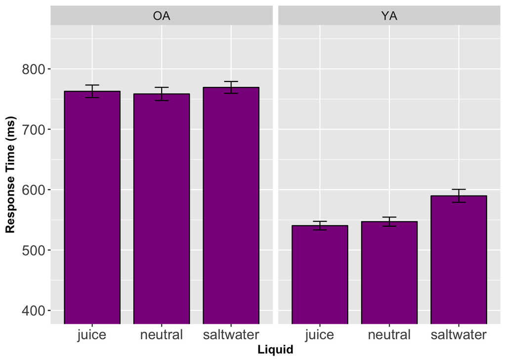

```r
p.RT.2<-ggplot(RT.sum, aes(x=liquid, y=meanRT)) +
  geom_bar(position=position_dodge(width=0.8), color="black",
           fill='darkmagenta', stat="identity", width=0.8) +
  geom_errorbar(position=position_dodge(width=0.8),
                aes(ymin=meanRT-se, ymax=meanRT+se), width=.2) +
  facet_grid(.~group) +
  xlab("Liquid") + ylab("Response Time (ms)") +
  #ggtitle("Task Performance Across Money") +
  coord_cartesian(ylim=c(400,850)) +
  scale_fill_discrete(name="Monetary Reward") +
  theme(#plot.title=element_text(size=22,face="bold", vjust=2),
        axis.title=element_text(size=12,face = "bold"),
        axis.text=element_text(size=14),
        legend.position="none",
        strip.text.x = element_text(size = 12))
p.RT.2
```

# RT by block and age group

```r
RT.sum=summarySEwithin2(data=rewRT.means, measurevar = "meanRT", withinvars = c("block"),
                        betweenvars = c("group"), idvar = "subID")
pandoc.table(RT.sum)
```

```
##
## ---------------------------------------------------------------------
##  group   block    N    meanRT   meanRTNormed    sd      se      ci
## ------- ------- ----- -------- -------------- ------- ------- -------
##   OA       1     132   812.3        700        84.75   7.377   14.59
##
##   OA       2     132   741.6       629.4       68.07   5.924   11.72
##
##   OA       3     132   736.7       624.4       67.85   5.906   11.68
##
##   YA       1     162   580.1       671.7       82.19   6.457   12.75
##
##   YA       2     161   551.9       643.6       91.2    7.188   14.2
##
##   YA       3     162   546.9       638.5       91.2    7.165   14.15
## ---------------------------------------------------------------------
```

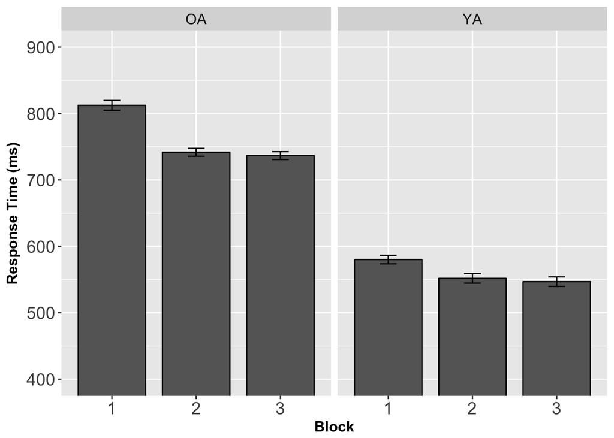

```r
p.RT.3<-ggplot(RT.sum, aes(x=block, y=meanRT)) +
  geom_bar(position=position_dodge(width=0.8), color="black",
           fill='gray40', stat="identity", width=0.8) +
  geom_errorbar(position=position_dodge(width=0.8),
                aes(ymin=meanRT-se, ymax=meanRT+se), width=.2) +
  facet_grid(.~group) +
  xlab("Block") + ylab("Response Time (ms)") +
  #ggtitle("Task Performance Across Money") +
  coord_cartesian(ylim=c(400,900)) +
  scale_fill_discrete(name="Monetary Reward") +
  theme(#plot.title=element_text(size=22,face="bold", vjust=2),
        axis.title=element_text(size=12,face = "bold"),
        axis.text=element_text(size=14),
        legend.position="none",
        strip.text.x = element_text(size = 12))
p.RT.3
```

# RT by money, block and age group

```r
RT.sum=summarySEwithin2(data=rewRT.means, measurevar = "meanRT", withinvars = c("money","block"),
                        betweenvars = c("group"), idvar = "subID")
pandoc.table(RT.sum)
```

```
##
## ----------------------------------------------------------------------------
##  group   money   block   N    meanRT   meanRTNormed    sd      se      ci
## ------- ------- ------- ---- -------- -------------- ------- ------- -------
##   OA       $       1     44   805.5       693.3       69.94   10.54   21.26
##
##   OA       $       2     44   745.1       632.8       59.72   9.002   18.16
##
##   OA       $       3     44   747.9       635.7       67.71   10.21   20.59
##
##   OA      $$       1     44   819.8       707.6       65.41   9.861   19.89
##
##   OA      $$       2     44   750.2        638        53.75   8.104   16.34
##
##   OA      $$       3     44   745.9       633.7       57.01   8.594   17.33
##
##   OA     $$$$      1     44   811.4       699.2       84.39   12.72   25.66
##
##   OA     $$$$      2     44   729.6       617.3       62.16   9.371   18.9
##
##   OA     $$$$      3     44   716.2        604        44.27   6.674   13.46
##
##   YA       $       1     54   590.6       682.2       78.96   10.74   21.55
##
##   YA       $       2     54   567.2       658.8       73.13   9.951   19.96
##
##   YA       $       3     54    559        650.5       95.14   12.95   25.97
##
##   YA      $$       1     54   597.6       689.2       60.76   8.269   16.59
##
##   YA      $$       2     53    562        654.3       85.95   11.81   23.69
##
##   YA      $$       3     54   561.5       653.1       78.43   10.67   21.41
##
##   YA     $$$$      1     54   552.2       643.7       63.95   8.702   17.45
##
##   YA     $$$$      2     54   526.5       618.1       71.4    9.717   19.49
##
##   YA     $$$$      3     54   520.2       611.8       50.19   6.83    13.7
## ----------------------------------------------------------------------------
```

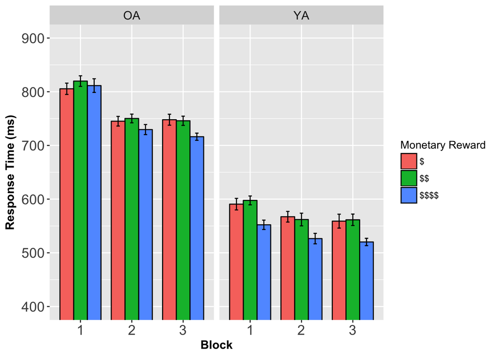

```r
p.RT.4<-ggplot(RT.sum, aes(x=block, y=meanRT, fill=money)) +
  geom_bar(position=position_dodge(width=0.8), color="black",
           stat="identity", width=0.8) +
  geom_errorbar(position=position_dodge(width=0.8),
                aes(ymin=meanRT-se, ymax=meanRT+se), width=.2) +
  facet_grid(.~group) +
  xlab("Block") + ylab("Response Time (ms)") +
  #ggtitle("Task Performance Across Money") +
  coord_cartesian(ylim=c(400,900)) +
  scale_fill_discrete(name="Monetary Reward") +
  theme(#plot.title=element_text(size=22,face="bold", vjust=2),
        axis.title=element_text(size=12,face = "bold"),
        axis.text=element_text(size=14),
        legend.position="right",
        strip.text.x = element_text(size = 12))
p.RT.4
```

# Accuracy by block and age group

```r
ACC.sum=summarySEwithin2(data=rew.means, measurevar = "meanACC", withinvars = c("block"),
                        betweenvars = c("group"), idvar = "subID")
pandoc.table(ACC.sum)
```

```
##
## ------------------------------------------------------------------------------
##  group   block    N    meanACC   meanACCNormed     sd         se        ci
## ------- ------- ----- --------- --------------- --------- ---------- ---------
##   OA       1     132   0.8598        0.826       0.07908   0.006883   0.01362
##
##   OA       2     132   0.8601       0.8263       0.08085   0.007037   0.01392
##
##   OA       3     132   0.8802       0.8464       0.08213   0.007149   0.01414
##
##   YA       1     162   0.8328       0.8603       0.1243    0.009767   0.01929
##
##   YA       2     162   0.7907       0.8182       0.1134    0.008912   0.0176
##
##   YA       3     162   0.7926       0.8202       0.1456    0.01144    0.02259
## ------------------------------------------------------------------------------
```

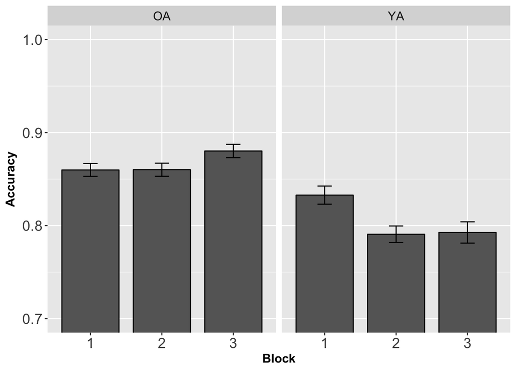

```r
p.ACC.1<-ggplot(ACC.sum, aes(x=block, y=meanACC)) +
  geom_bar(position=position_dodge(width=0.8), color="black",
           fill='gray40', stat="identity", width=0.8) +
  geom_errorbar(position=position_dodge(width=0.8),
                aes(ymin=meanACC-se, ymax=meanACC+se), width=.2) +
  facet_grid(.~group) +
  xlab("Block") + ylab("Accuracy") +
  #ggtitle("Task Performance Across Money") +
  coord_cartesian(ylim=c(0.7,1)) +
  scale_fill_discrete(name="Monetary Reward") +
  theme(#plot.title=element_text(size=22,face="bold", vjust=2),
        axis.title=element_text(size=12,face = "bold"),
        axis.text=element_text(size=14),
        legend.position="right",
        strip.text.x = element_text(size = 12))
p.ACC.1
```

# Accuracy by money, block and age group

```r
ACC.sum=summarySEwithin2(data=rew.means, measurevar = "meanACC", withinvars = c("money","block"),
                        betweenvars = c("group"), idvar = "subID")
pandoc.table(ACC.sum)
```

```
##
## -------------------------------------------------------------------------------------
##  group   money   block   N    meanACC   meanACCNormed     sd         se        ci
## ------- ------- ------- ---- --------- --------------- --------- ---------- ---------
##   OA       $       1     44   0.8608        0.827       0.07404   0.01116    0.02251
##
##   OA       $       2     44   0.8594       0.8256       0.07522   0.01134    0.02287
##
##   OA       $       3     44   0.8636       0.8298       0.06606   0.009959   0.02008
##
##   OA      $$       1     44   0.8494       0.8156       0.07535   0.01136    0.02291
##
##   OA      $$       2     44   0.8658        0.832       0.05757   0.00868    0.0175
##
##   OA      $$       3     44   0.8771       0.8433       0.07132   0.01075    0.02168
##
##   OA     $$$$      1     44   0.8693       0.8355       0.05387   0.008121   0.01638
##
##   OA     $$$$      2     44   0.8551       0.8213       0.07678   0.01157    0.02334
##
##   OA     $$$$      3     44   0.8999       0.8661       0.07205   0.01086    0.0219
##
##   YA       $       1     54   0.8154       0.8429       0.1097    0.01493    0.02995
##
##   YA       $       2     54   0.7841       0.8117       0.09425   0.01283    0.02573
##
##   YA       $       3     54   0.7506       0.7781       0.1557    0.02118    0.04249
##
##   YA      $$       1     54   0.8391       0.8667       0.1179    0.01604    0.03218
##
##   YA      $$       2     54   0.7841       0.8117       0.1081     0.0147    0.02949
##
##   YA      $$       3     54   0.7841       0.8117       0.1153    0.01569    0.03146
##
##   YA     $$$$      1     54   0.8438       0.8713       0.09346   0.01272    0.02551
##
##   YA     $$$$      2     54   0.8038       0.8314       0.09196   0.01251    0.0251
##
##   YA     $$$$      3     54   0.8432       0.8707       0.07569    0.0103    0.02066
## -------------------------------------------------------------------------------------
```

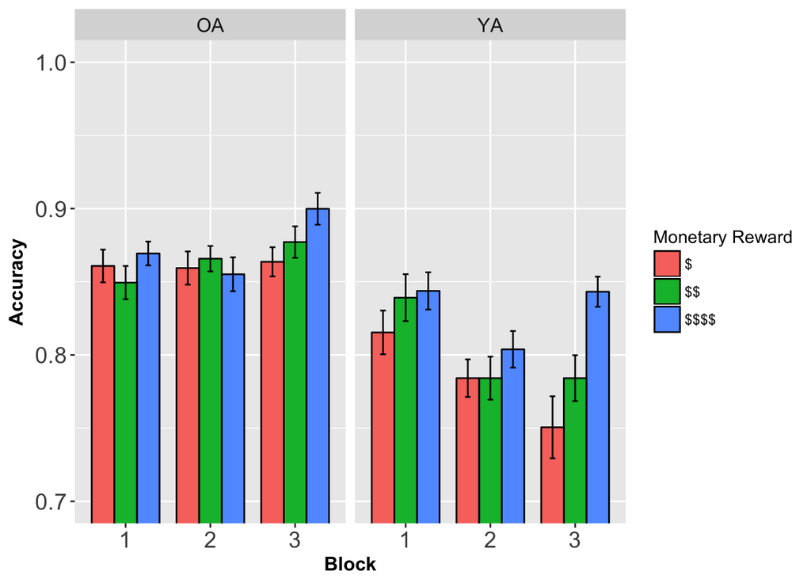

```r
p.ACC.2<-ggplot(ACC.sum, aes(x=block, y=meanACC, fill=money)) +
  geom_bar(position=position_dodge(width=0.8), color="black",
           stat="identity", width=0.8) +
  geom_errorbar(position=position_dodge(width=0.8),
                aes(ymin=meanACC-se, ymax=meanACC+se), width=.2) +
  facet_grid(.~group) +
  xlab("Block") + ylab("Accuracy") +
  #ggtitle("Task Performance Across Money") +
  coord_cartesian(ylim=c(0.7,1)) +
  scale_fill_discrete(name="Monetary Reward") +
  theme(#plot.title=element_text(size=22,face="bold", vjust=2),
        axis.title=element_text(size=12,face = "bold"),
        axis.text=element_text(size=14),
        legend.position="right",
        strip.text.x = element_text(size = 12))
p.ACC.2
```

## Cog Aging 2018 Poster

```r
# Cog Aging path
cog.path="/Users/debbieyee/Documents/Conferences/2018/Cognitive Aging/Figures/"
ggsave(filename = "Study1_RR_money.eps", plot = p.RR.1, device = "eps",
       path = cog.path, width = 5.5, height = 5, scale = 1)
ggsave(filename = "Study1_RR_liquid.eps", plot = p.RR.2, device = "eps",
       path = cog.path, width = 5.5, height = 5, scale = 1)
ggsave(filename = "Study1_RR_moneyliquid.eps", plot = p.RR.3, device = "eps",
       path = cog.path, width = 8, height = 5, scale = 1)
ggsave(filename = "Study1_RR_block.eps", plot = p.RR.5, device = "eps",
       path = cog.path, width = 5.5, height = 5, scale = 1)
ggsave(filename = "Study1_RR_moneyblock.eps", plot = p.RR.6, device = "eps",
       path = cog.path, width = 7, height = 5, scale = 1)
ggsave(filename = "Study1_ACC_moneyblock.eps", plot = p.ACC.2, device = "eps",
       path = cog.path, width = 7, height = 4, scale = 1)
ggsave(filename = "Study1_RT_moneyblock.eps", plot = p.RT.4, device = "eps",
       path = cog.path, width = 7, height = 4, scale = 1)
```